# Missingness analysis

Amelia Tan, Arianna Dagliati, Trang Le, Alba Gutierrez

4 November 2020

```r
library(ggplot2)
library(readr)
library(dplyr)
library(tidyr)
library(forcats)
library(DT)
library(tibble)
library(cowplot)
theme_set(theme_bw() +
            theme(legend.title = element_blank(),
                  panel.grid.minor = element_blank()))
```

## Read in files

and convert to wide format

```r
#4CE long format Labs Data
#patient_obs <- read_csv('./missingness/patients-observations.csv')
patient_obs <- read_csv('/4ceData/Input/LocalPatientObservations.csv')
patient_obs <- patient_obs[ patient_obs$concept_type == "LAB-LOINC",]
#IDs of severe subject and date of the first severe event
#severity <- read_csv('./missingness/severity.csv')
severity <- read_csv('/4ceData/Input/LocalPatientSummary.csv')
severity <- severity[ severity$severe == 1, c("patient_num", "severe_date")]
colnames(severity) <- c("covid_id", "data_evento")
#Code, Descriptions and Ranges
lab_mapping <- read_csv('/4ceData/missingness/loinc-map.csv')
```

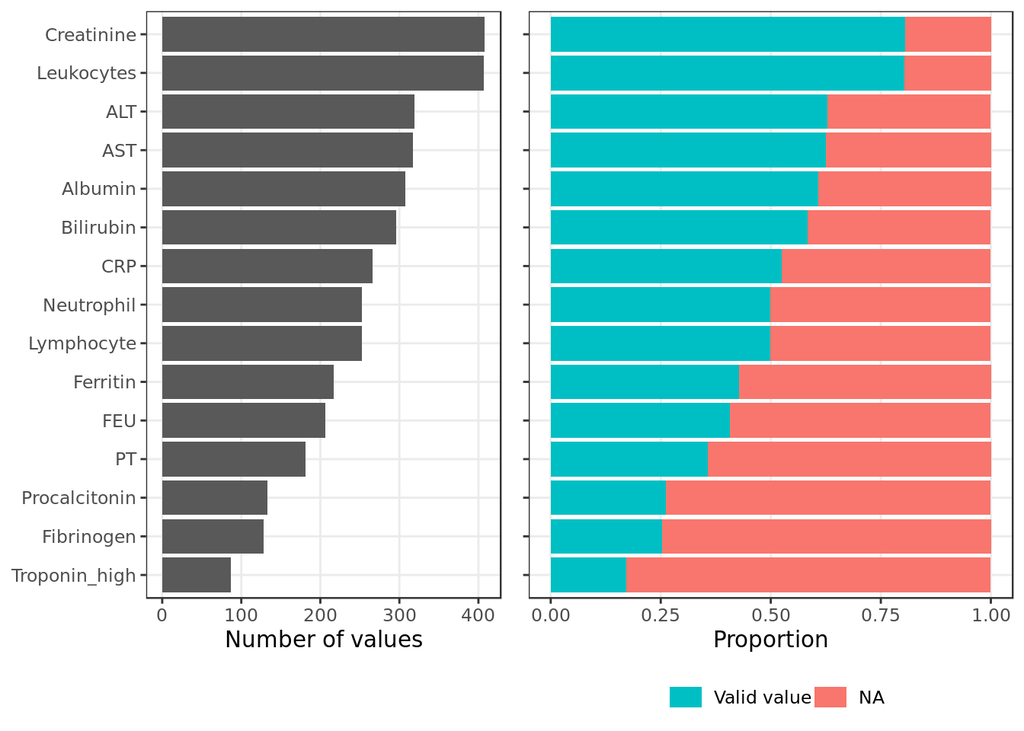

```r
patient_obs_wide <- patient_obs %>%
  left_join(lab_mapping, by = c('concept_code' = 'LOINC')) %>%
  select(- concept_code) %>%
  pivot_wider(id_cols = c(patient_num, days_since_admission),
              names_from = short_name,
              values_from = value,
              values_fn = mean)
#check NAs in the Wide format
na_stats <- patient_obs_wide %>%
  select(- c(patient_num, days_since_admission)) %>%
  is.na() %>%
  `!`
na_df <- data.frame(value_existed = colSums(na_stats),
           prop_existed = colMeans(na_stats)) %>%
  rownames_to_column('lab') %>%
  mutate(prop_na = 1 - prop_existed,
         lab = fct_reorder(lab, value_existed))
n_values <- na_df %>%
  ggplot(aes(x = value_existed, y = lab)) +
  geom_col() +
  labs(x = 'Number of values', y = NULL)
na_prob <- na_df %>%
  rename('Valid value' = prop_existed, 'NA' = prop_na) %>%
  pivot_longer(c(`Valid value`, `NA`)) %>%
  ggplot(aes(x = value, y = lab, fill = name)) +
  geom_col() +
  scale_fill_discrete(guide = guide_legend(reverse = TRUE)) +
  labs(x = 'Proportion', y = NULL) +
  #guides(fill = guide_legend(reverse = TRUE))+
  theme(
    axis.text.y = element_blank(),
    legend.key.width = unit(6, 'mm'),
    legend.key.height = unit(4, 'mm'),
    legend.position = 'bottom')
plot_grid(n_values, na_prob, nrow = 1, axis = 'b', align = 'h')
```

## Number of observation (days) per patient

```r
days_count_min_max <- patient_obs_wide %>%
  group_by(patient_num) %>%
  summarise(
    n = n_distinct(days_since_admission),
    min = min(days_since_admission),
    max = max(days_since_admission),
    .groups = 'drop'
  ) %>%
  mutate(time_obs = max - min,
         severity = patient_num %in% unique(severity$covid_id))
n_severe <- sum(days_count_min_max$severity)
n_nonsevere <- sum(!days_count_min_max$severity)
   summary(days_count_min_max$n)
```

```
##    Min. 1st Qu.  Median    Mean 3rd Qu.    Max.
##   1.000   2.000   6.000   8.593  11.000  43.000
```

## Histogram of the number of days with at least one observation

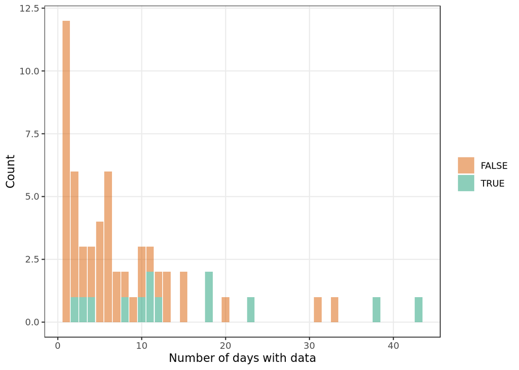

```r
days_bar <- days_count_min_max %>%
  ggplot(aes(x = n, fill = severity)) +
  geom_bar(alpha = 0.5) +
  scale_fill_brewer(palette = 'Dark2', direction = -1) +
  labs(fill = 'Severe?',
       x = "Number of days with data",
       y = "Count")
days_bar
```

## Histogram of length of stay

i.e. last day with observation-first day with observation

We need to check for readmission here.

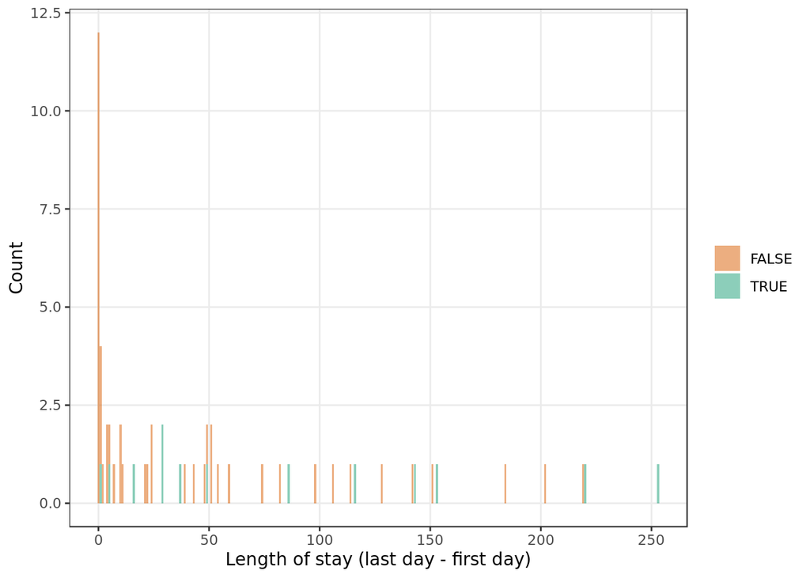

```r
period_bar <- days_count_min_max %>%
  ggplot(aes(x = time_obs, fill = severity)) +
  geom_bar(alpha = 0.5) +
  scale_fill_brewer(palette = 'Dark2', direction = -1) +
  labs(fill = 'Severe?',
       x = "Length of stay (last day - first day)",
       y = "Count")
period_bar
```

## Analyze missingness and frequency of measures for each lab

```r
patient_obs_long <- patient_obs_wide %>%
  pivot_longer(-c(patient_num, days_since_admission),
               names_to = 'lab', values_to = 'value',
               values_drop_na = TRUE) %>%
  mutate(severity = as.character(patient_num %in%
      unique(severity$covid_id))%>%
      as_factor() %>%
      fct_recode('nonsevere' = 'FALSE', 'severe' = 'TRUE'))

per_lab <- patient_obs_long %>%
  group_by(lab, patient_num, severity) %>%
  count(name = 'n_obs') %>%
  ungroup() %>%
  group_by(lab, severity) %>%
  count(n_obs) %>%
  ungroup() %>%
  pivot_wider(names_from = severity, values_from = n, values_fill = 0) %>%
  mutate(both_severities = nonsevere + severe) %>%
  mutate(prop_nonsevere = nonsevere/n_nonsevere,
         prop_severe = severe/n_severe,
         prop_both = both_severities/nrow(days_count_min_max))
lab_medians <-
  patient_obs_long %>%
  add_count(lab, name = 'total_obs') %>%
  group_by(lab) %>%
  mutate(total_patients = length(unique(patient_num))) %>%
  add_count(patient_num, name = 'n_obs_patients') %>%
  mutate(median_obs_per_patient = median(n_obs_patients),
         n_greater0 = n_obs_patients > median_obs_per_patient,
         n_greater1 = n_obs_patients > median_obs_per_patient + 1,
         n_greater2 = n_obs_patients > median_obs_per_patient + 2) %>%
  group_by(severity) %>%
  mutate(each_med_obs_per_patient = median(n_obs_patients)) %>%
  ungroup(severity) %>%
  select(- c(days_since_admission, value)) %>%
  distinct() %>%
  group_by(lab) %>%
  mutate(across(contains('n_greater'), sum)) %>%
  select(- c(n_obs_patients, patient_num)) %>%
  distinct() %>%
  pivot_wider(names_from = severity, values_from = each_med_obs_per_patient) %>%
  rename('median_obs_per_severe_patient' = severe,
         'median_obs_per_non_severe_patient' = nonsevere) %>%
  select(lab, total_obs, total_patients, starts_with('med'), starts_with('n_'))
lab_medians %>%
  datatable(rownames = FALSE)
```

| lab | total_obs | total_patients | median_obs_per_patient | median_obs_per_non_severe_patient | median_obs_per_severe_patient | n_greater0 | n_greater1 | n_greater2 |
| --- | --- | --- | --- | --- | --- | --- | --- | --- |
| CRP | 266 | 40 | 9 | 9 | 15 | 7 | 7 | 5 |
| Leukocytes | 407 | 53 | 13 | 9 | 15 | 8 | 8 | 8 |
| Lymphocyte | 253 | 44 | 10 | 9 | 15 | 6 | 6 | 5 |
| Neutrophil | 253 | 44 | 10 | 9 | 15 | 6 | 6 | 5 |
| ALT | 319 | 41 | 12 | 9 | 15 | 8 | 7 | 7 |
| Albumin | 308 | 39 | 12 | 9 | 15 | 8 | 7 | 6 |
| AST | 317 | 41 | 12 | 9 | 15 | 8 | 7 | 7 |
| Bilirubin | 296 | 39 | 12 | 9 | 15 | 7 | 6 | 6 |
| Creatinine | 408 | 54 | 12.5 | 9 | 15 | 10 | 8 | 8 |
| PT | 181 | 35 | 8 | 9 | 15 | 6 | 5 | 3 |

[output cut: 5 more lines]

`n_greater0` shows the number of patients who had more observations than the median. `n_greater1` shows the number of patients who had more observations than the median + 1. `n_greater2` shows the number of patients who had more observations than the median + 2.

In the figure below:

- Dash line: `Reference Low`
- Solid line: `Reference High`

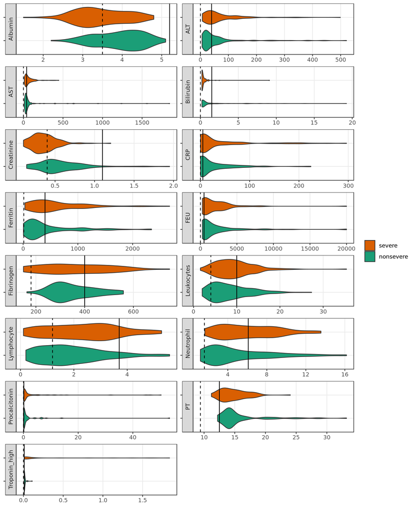

```r
patient_obs_long %>%
  left_join(lab_mapping, by = c('lab' = 'short_name')) %>%
  ggplot(aes(y = severity, x = value, fill = severity)) +
  geom_violin() +
  geom_vline(aes(xintercept = `Reference Low`), linetype = 'dashed') +
  scale_fill_brewer(palette = 'Dark2', guide = guide_legend(reverse = TRUE)) +
  labs(y = NULL, x = NULL) +
  geom_vline(aes(xintercept = `Reference High`)) +
  facet_wrap(~ lab, scales = 'free', ncol = 2, strip.position = 'left') +
  theme(axis.text.y = element_blank())
```

## Heatmap of number of observations per lab

Numbers in the cells represent the number of patients with that particular number of oberservations. This is especially relevant for ML/modelling tasks where having a subtantial number of samples is important.

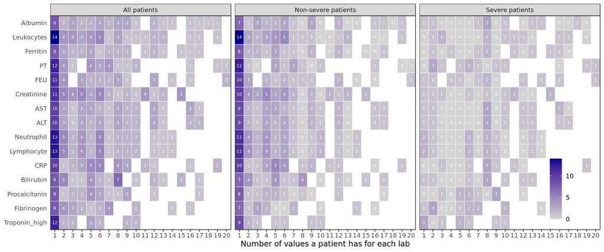

```r
per_lab %>%
  select(lab, n_obs, both_severities, severe, nonsevere) %>%
  filter(n_obs <= 20) %>%
  pivot_longer(c(both_severities, severe, nonsevere)) %>%
  mutate(name = name %>% fct_recode(
    'All patients' = 'both_severities',
    'Severe patients' = 'severe',
    'Non-severe patients' = 'nonsevere'
  )) %>%
  ggplot(aes(x = n_obs, fill = value, y = fct_reorder(lab, n_obs))) +
  geom_tile(colour = "white", size = 0.2)+
  geom_text(aes(label = value), colour = "white", size = 2) +
  scale_y_discrete(expand = c(0, 0))+
  scale_x_continuous(expand = c(0, 0),
                     breaks = c(1:max(per_lab$n_obs)),
                     labels = c(1:max(per_lab$n_obs)))+
  scale_fill_gradient(low = "lightgrey", high = "darkblue",
                      limits = c(0, max(per_lab$both_severities))) +
  facet_wrap(~ name, nrow = 1) +
  labs(x = 'Number of values a patient has for each lab',
       y = NULL, fill = '# patients') +
  theme(panel.grid.major = element_blank(),
        legend.position = c(0.93, 0.2),
        axis.ticks.y = element_blank()
  )
```

## Heatmap of % patients with X number of obeservations per lab

This figures tells us the porportion of (all, nonsevere and severe) patients with X number of observations. From this we can infer if particular labs are more utilised in different groups of patients

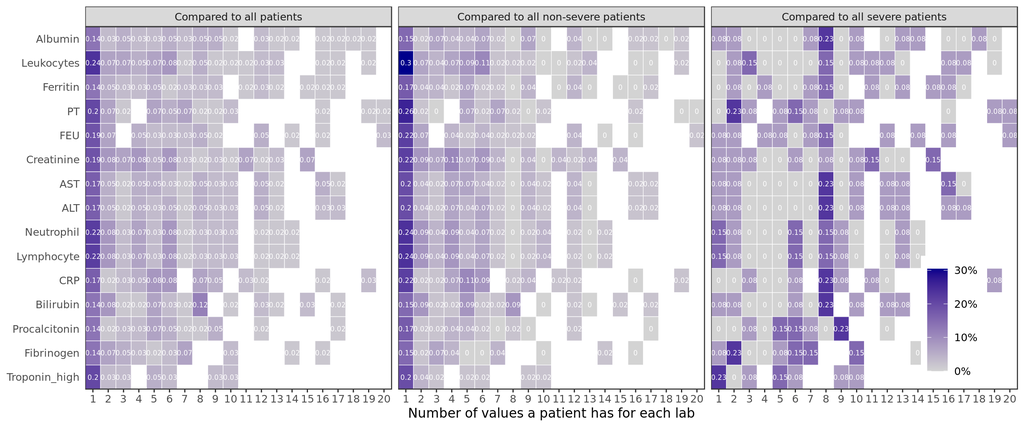

```r
per_lab %>%
  select(lab, n_obs, prop_both, prop_severe, prop_nonsevere) %>%
  filter(n_obs <= 20) %>%
  pivot_longer(c(prop_both, prop_severe, prop_nonsevere)) %>%
  mutate(name = name %>% fct_recode(
    'Compared to all patients' = 'prop_both',
    'Compared to all severe patients' = 'prop_severe',
    'Compared to all non-severe patients' = 'prop_nonsevere'
  )) %>%
  ggplot(aes(x = n_obs, fill = value, y = fct_reorder(lab, n_obs))) +
  geom_tile(colour = "white", size = 0.2)+
  geom_text(aes(label = round(value, 2)), colour = "white", size = 2) +
  scale_y_discrete(expand = c(0, 0)) +
  scale_x_continuous(expand = c(0, 0),
                     breaks = c(1:max(per_lab$n_obs)),
                     labels = c(1:max(per_lab$n_obs)))+
  scale_fill_gradient(low = "lightgrey", high = "darkblue",
                      labels = scales::percent_format(accuracy = 1L)) +
  facet_wrap(~ name, nrow = 1) +
  labs(x = 'Number of values a patient has for each lab',
       y = NULL, fill = '# patients') +
  theme(panel.grid.major = element_blank(),
        legend.position = c(0.93, 0.2),
        axis.ticks.y = element_blank()
  )
```

Denominator: total number of patients, total number of non-severe patients, and total number of severe patients, respectively.